# Naïve Bayes

MDS. René Rosado González

## Introduction

You will work with the `bes` dataset from *Llaudet, E., & Imai, K. (2022). Data Analysis for Social Science: A Friendly and Practical Introduction* book. This dataset contains the voting intention about Brexit, considering people age and education. Fill in the blanks in order to build a naive bayes classification model.

## Libraries

Load, and install if necessary, the `tidyverse` and `tidymodels` libraries, as well as the `discrim` package.

```r
# Install - load tidyverse
if(require(tidyverse) == FALSE){
  install.packages('tidyverse')
  library(tidyverse)
}else{
  library(tidyverse)
}
# Install - load tidymodels
if(require(tidymodels) == FALSE){
  install.packages('tidymodels')
  library(tidymodels)
}else{
  library(tidymodels)
}
# Install - load discrim
if(require(discrim) == FALSE){
  install.packages('discrim')
  library(discrim)
}else{
  library(discrim)
}
```

## Dataset

Load the `BES.csv` file.

```r
# Read csv
bes = read_csv('../data/BES.csv')
```

## Exploratory Data Analysis (EDA)

Perform an exploratory data analysis using the `glimpse` and `summary` functions.

```r
## Tidyway
glimpse(bes)
```

```
## Rows: 30,895
## Columns: 4
## $ vote      <chr> "leave", "leave", "stay", "leave", "don't know", "stay", "le…
## $ leave     <dbl> 1, 1, 0, 1, NA, 0, 1, 1, 1, 1, 0, 1, 1, 1, 1, 1, 0, 0, 1, 0,…
## $ education <dbl> 3, NA, 5, 4, 2, 4, 3, 2, 3, 4, 4, 4, 4, 4, NA, 3, 2, 2, NA, …
## $ age       <dbl> 60, 56, 73, 64, 68, 85, 78, 51, 59, 68, 53, 52, 70, 39, 48, …
```

```r
# Summary
summary(bes)
```

```
##      vote               leave          education          age
##  Length:30895       Min.   :0.0000   Min.   :1.000   Min.   :18.00
##  Class :character   1st Qu.:0.0000   1st Qu.:2.000   1st Qu.:37.00
##  Mode  :character   Median :0.0000   Median :3.000   Median :53.00
##                     Mean   :0.4882   Mean   :3.226   Mean   :50.75
##                     3rd Qu.:1.0000   3rd Qu.:4.000   3rd Qu.:64.00
##                     Max.   :1.0000   Max.   :5.000   Max.   :97.00
##                     NA's   :2851     NA's   :3425
```

Count the observations based on the `vote` and `leave` columns. What can you see?

```r
# Count
bes %>%
  count(vote, leave)
```

```
## # A tibble: 4 × 3
##   vote       leave     n
##   <chr>      <dbl> <int>
## 1 don't know    NA  2314
## 2 leave          1 13692
## 3 stay           0 14352
## 4 won't vote    NA   537
```

For the porpuse of this excersise we will focus only in those obsevations with a declared `leave` intention. This imply you must filter the data where `leave` is not an `NA`.

```r
bes = bes %>%
  # Filter the NA in the leave column
  filter(!is.na(leave)) %>%
  # Transform the vote column into a factor with 'stay' and 'leave' as levels
  mutate(vote = factor(vote, levels = c('stay', 'leave')))

# Look at a summary
summary(bes)
```

```
##     vote           leave          education          age
##  stay :14352   Min.   :0.0000   Min.   :1.000   Min.   :18.00
##  leave:13692   1st Qu.:0.0000   1st Qu.:2.000   1st Qu.:38.00
##                Median :0.0000   Median :3.000   Median :54.00
##                Mean   :0.4882   Mean   :3.242   Mean   :51.16
##                3rd Qu.:1.0000   3rd Qu.:4.000   3rd Qu.:65.00
##                Max.   :1.0000   Max.   :5.000   Max.   :97.00
##                                 NA's   :2947
```

Use the `ggdist` package to graph a boxplot and halfeye plot in the same graph. Set the `vote` column in the x axis, and `age` for the y axis. What pattern can you observe?

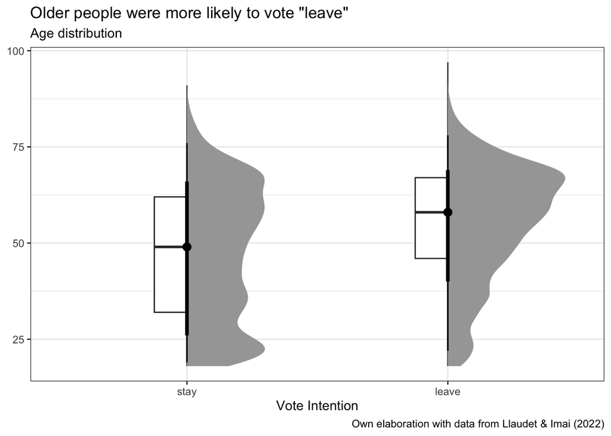

```r
# Install - ggdist
if(require(ggdist) == FALSE){
  install.packages('ggdist')
  library(ggdist)
} else {
  library(ggdist)
}

# Create a ggplot
ggplot(bes, aes(x = vote, y = age)) +
  # Add a stat_boxplot with a width of 0.25
  stat_boxplot(width = 0.25) +
  # Add a stat_halfeye with a width of 0.5
  stat_halfeye(width = 0.5) +
  # Add proper labels
  labs(
     # Modify the x and y axis labels to make them clearer
    x = 'Vote Intention',
    title = 'Older people were more likely to vote "leave"',
    subtitle = 'Age distribution',
    # Add the following caption
    caption = 'Own elaboration with data from Llaudet & Imai (2022)'
  ) +
  # Use a default theme
  theme_bw() +
  # Modify legend attributes using legend.attribute
  theme(
    axis.title.y = element_blank(),
    legend.background = element_blank(),
    legend.box.background = element_blank(),
    legend.key = element_rect(fill = "transparent"),
    legend.position = c(0.05, 0.9),
    legend.key.height = unit(0.5,'cm')
  )
```

Count the number of observations based on the `vote` and `education` columns. THen calculate the percentage of observations by voting preferences in each educational level, and create a column plot using this data. What pattern can you observe?

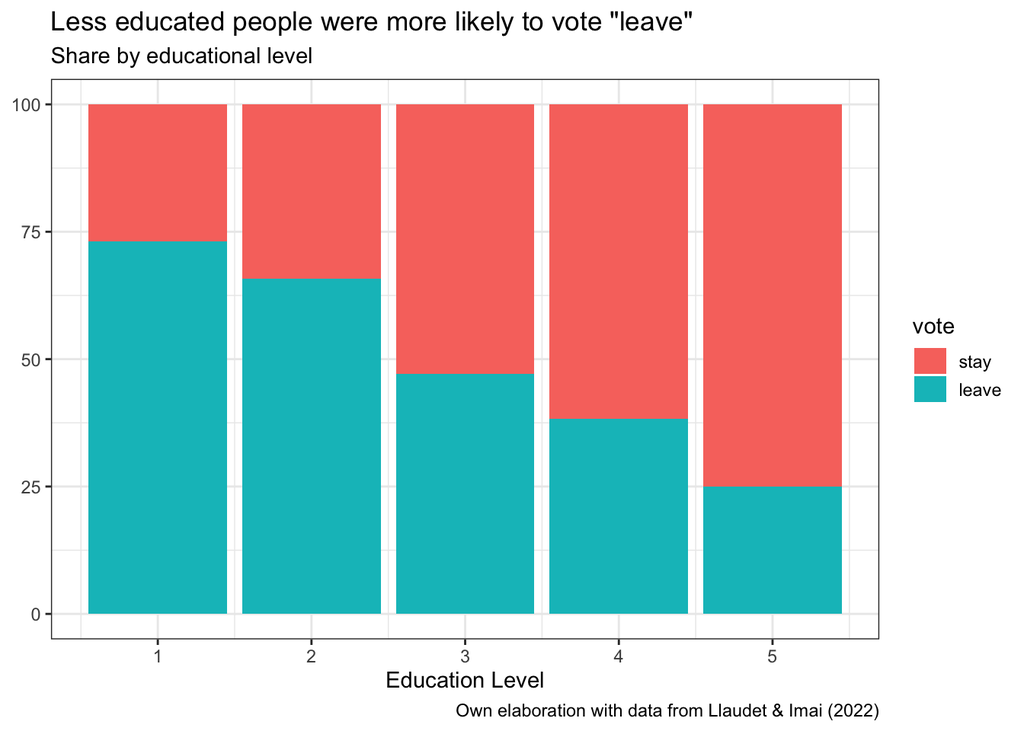

```r
bes %>%
  # Count observations
  count(vote, education) %>%
  # Perform operations by group
  with_groups(
    # Use education as grouping variable
    .groups = education,
    # Set the mutate operation
    mutate,
    # calculate the percentage
    pct = 100 * n/sum(n)
  ) %>%
  # Create a ggplot
  ggplot(aes(x = education, y = pct)) +
  # Color by vote
  geom_col(aes(fill = vote)) +
  # Add proper labels
  labs(
     # Modify the x and y axis labels to make them clearer
    x = 'Education Level',
    title = 'Less educated people were more likely to vote "leave"',
    subtitle = 'Share by educational level',
    # Add the following caption
    caption = 'Own elaboration with data from Llaudet & Imai (2022)',
    col = 'Voted'
  ) +
  # Use a default theme
  theme_bw() +
  # Modify legend attributes using legend.attribute
  theme(
    axis.title.y = element_blank(),
    legend.background = element_blank(),
    legend.box.background = element_blank(),
    legend.key = element_rect(fill = "transparent"),
    legend.key.height = unit(0.5,'cm')
  )
```

## Naive Bayes Classification

Create a model specification for the naive bayes using the `tidymodels` framework.

```r
nb_model = naive_Bayes() %>%
  # Set the engine
  set_engine("klaR")  %>%
  # Set the mode
  set_mode("classification") %>%
  # Set hyperparameters to tune
  set_args(
    Laplace = tune(),
    smoothness = tune()
    )
```

Make an initial data split with 75% of the observations in the training set. To get consistent results lets set a random seed of `123`.

```r
# Data splitting for samples
set.seed(123)
bes_split = initial_split(
  # Data to split
  data = bes,
  # Proportions
  prop = 0.75,
  # Variable of interest
  strata = vote
)

# Get training and testing samples
bes_training = training(bes_split)
bes_testing = testing(bes_split)
```

Create 5 cross validation folds from the training set.

```r
# Create cross-validation folds
set.seed(123)
bes_folds = vfold_cv(bes_training, v = 5)
```

Create the following recipe to predict the `vote` in function of age and education.

```r
# Create a recipe
recipe = recipe(
  # Set a formula
  formula = vote ~ age + education,
  # Set input data
  data = bes_training
) %>%
  # Impute missing values in the education column using knn
  step_impute_knn(education) %>%
  # Transform number to factor in the education column
  step_num2factor(education, levels = as.character(c(1:5)))
```

Make a workflow object with the recipe and model you just created.

```r
# Create a workflow
nb_workflow = workflow() %>%
  # Add your recipe
  add_recipe(recipe) %>%
  # Add your model
  add_model(nb_model)
```

Perform hyperparameter tuning on the workflow you just created using a `grid` of size 15.

```r
# Get parameters to tune
nb_parameters = nb_workflow %>%
  extract_parameter_set_dials()

# Create a tune grid
set.seed(123)
nb_tuning = tune_grid(
  object = nb_workflow,
  resamples = bes_folds,
  param_info = nb_parameters,
  metrics = metric_set(yardstick::accuracy),
  control = control_grid(verbose = TRUE),
  grid = 15
  )
```

Collect the tuning metrics and select the best model based on the `accuracy` metric.

```r
# Collegt metrics
tuning_metrics = nb_tuning %>%
  collect_metrics() %>%
  # Arrange form higher mean to lower mean
  arrange(desc(mean))

# Select the best model
best_nb = nb_tuning %>%
  select_best("accuracy")

# Print the best model
print(best_nb)
```

```
## # A tibble: 1 × 3
##   smoothness Laplace .config
##        <dbl>   <dbl> <chr>
## 1      0.803    2.64 Preprocessor1_Model09
```

Finalize your workflow and make the last fit to collect the performance of the model with the testing sample. Is the machine actually learning something?

```r
# Finalize the workflow with the best model
final_nb = nb_workflow %>%
  finalize_workflow(best_nb)

# Make the last fit
results_nb = final_nb %>%
  last_fit(
    split = bes_split,
    metrics = metric_set(yardstick::accuracy)
    )

# Collect testing metrics
metrics_nb = results_nb %>%
  collect_metrics()

print(metrics_nb)
```

```
## # A tibble: 1 × 4
##   .metric  .estimator .estimate .config
##   <chr>    <chr>          <dbl> <chr>
## 1 accuracy binary         0.644 Preprocessor1_Model1
```

```r
# Print teh confussion matrix
results_nb %>%
  collect_predictions() %>%
  conf_mat(truth = vote, estimate = .pred_class)
```

```
##           Truth
## Prediction stay leave
##      stay  2384  1293
##      leave 1204  2130
```

Make predictions on the full dataset

```r
# Extract the trained model
nb_trained = results_nb %>%
  extract_fit_parsnip()

# Make the predictions
predictions_tb =  augment(nb_trained, recipe %>% prep %>% bake(new_data = bes))
```

Create a plot to asses the relationship betweent the probability of voting ‘leave’ against the age

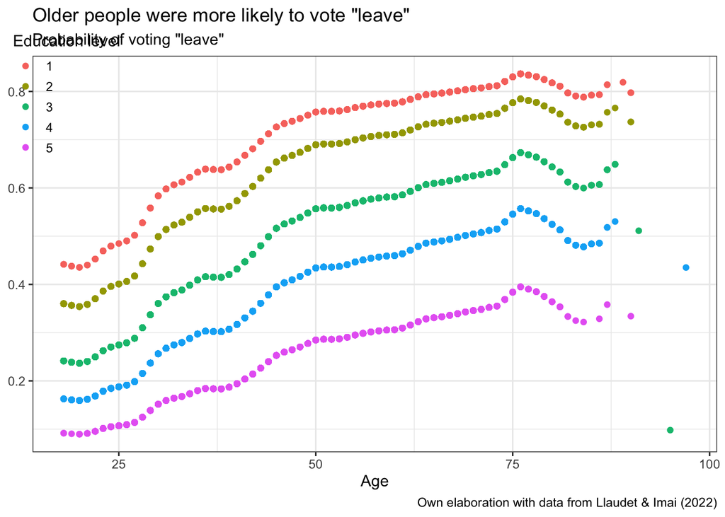

```r
# Plot decision boundaries
ggplot(predictions_tb, aes(x = age)) +
  # Add the observations
  geom_point(aes(y = .pred_leave, col = education)) +
  # Add proper labels
  labs(
    col = 'Education level',
     # Modify the x and y axis labels to make them clearer
    x = 'Age',
    title = 'Older people were more likely to vote "leave"',
    subtitle = 'Probability of voting "leave"',
    # Add the following caption
    caption = 'Own elaboration with data from Llaudet & Imai (2022)'
  ) +
  # Use a default theme
  theme_bw() +
  # Modify legend attributes using legend.attribute
  theme(
    axis.title.y = element_blank(),
    legend.background = element_blank(),
    legend.box.background = element_blank(),
    legend.key = element_rect(fill = "transparent"),
    legend.position = c(0.05, 0.9),
    legend.key.height = unit(0.5,'cm')
  )
```